# Voyages of Captive Africans

Nguyen_LSCM

7/24/2020

IMPUTE MISSING DATA FOR TIDYTUESDAY VOYAGES OF CAPTIVE AFRICANS WITH TIDYMODELS

This week’s Tidy Tuesday datasets reflect on Juneteenth, the date when the law abolishing salvery in the United States was finally enforced throughout the American South, and specifically Texas. My own education as a white woman i nthe United States has been gravely lacking in the history of enslaved people, their experiences, and their impact and legacy: I’m glad to spend some time in this screencast understanding more about the forced transport of African people using the Salve Voyages African Names database

## Explore the data

- Our modeling goal is to estimate whether some characteristics of the people trafficked by enslavers changed over the last several decades of the trans-Atlantic slave trade. Missing data can be a challenge with historical data, so we’ll use imputation

Let’s read in the data on African names and use `skimr` to see what’s there

```r
suppressMessages(library(tidyverse))
suppressMessages(library(tidymodels))
suppressMessages(library(kableExtra))
```

```r
african_names <- readr::read_csv("https://raw.githubusercontent.com/rfordatascience/tidytuesday/master/data/2020/2020-06-16/african_names.csv")
skimr::skim(african_names)
```

Data summary

| Name | african_names |
| --- | --- |
| Number of rows | 91490 |
| Number of columns | 11 |
| _______________________ |  |
| Column type frequency: |  |
| character | 6 |
| numeric | 5 |
| ________________________ |  |
| Group variables | None |

**Variable type: character**

| skim_variable | n_missing | complete_rate | min | max | empty | n_unique | whitespace |
| --- | --- | --- | --- | --- | --- | --- | --- |
| name | 0 | 1.00 | 2 | 24 | 0 | 62330 | 0 |
| gender | 12878 | 0.86 | 3 | 5 | 0 | 4 | 0 |
| ship_name | 1 | 1.00 | 2 | 59 | 0 | 443 | 0 |
| port_disembark | 0 | 1.00 | 6 | 19 | 0 | 5 | 0 |
| port_embark | 1126 | 0.99 | 4 | 31 | 0 | 59 | 0 |
| country_origin | 79404 | 0.13 | 3 | 31 | 0 | 563 | 0 |

**Variable type: numeric**

| skim_variable | n_missing | complete_rate | mean | sd | p0 | p25 | p50 | p75 | p100 | hist |
| --- | --- | --- | --- | --- | --- | --- | --- | --- | --- | --- |
| id | 0 | 1.00 | 62122.02 | 51305.07 | 1.0 | 22935.25 | 45822.5 | 101263.8 | 199932 | ▇▆▃▁▂ |
| voyage_id | 0 | 1.00 | 17698.25 | 82016.88 | 557.0 | 2443.00 | 2871.0 | 3601.0 | 500082 | ▇▁▁▁▁ |
| age | 1126 | 0.99 | 18.89 | 8.60 | 0.5 | 11.00 | 20.0 | 26.0 | 77 | ▆▇▁▁▁ |
| height | 4820 | 0.95 | 58.61 | 6.84 | 0.0 | 54.00 | 60.0 | 64.0 | 85 | ▁▁▂▇▁ |
| year_arrival | 0 | 1.00 | 1831.40 | 9.52 | 1808.0 | 1826.00 | 1832.0 | 1837.0 | 1862 | ▂▆▇▃▁ |

There is data missing in both the gender and age variables, two I am interested in

This is a dataset of individual people who were liberated from slave ships. Where did the people in this dataset/ leave their ships?

```r
african_names %>%
               count(port_disembark, sort = TRUE) %>%
               kable()
```

| port_disembark | n |
| --- | --- |
| Freetown | 81009 |
| Havana | 10058 |
| Bahamas unspecified | 183 |
| Kingston, Jamaica | 144 |
| St. Helena | 96 |

Most of the freed captives in this database were liberated in either Freetown. Sierra Leone (so on the eastern side of the Atlantic) or Havana, Cuba (on the western side). Both cities had tribunals/courts to judge ships seized by anti-slaving patrols after European countries outlawed or restricted slavery

Where did these people start their forced journeys?

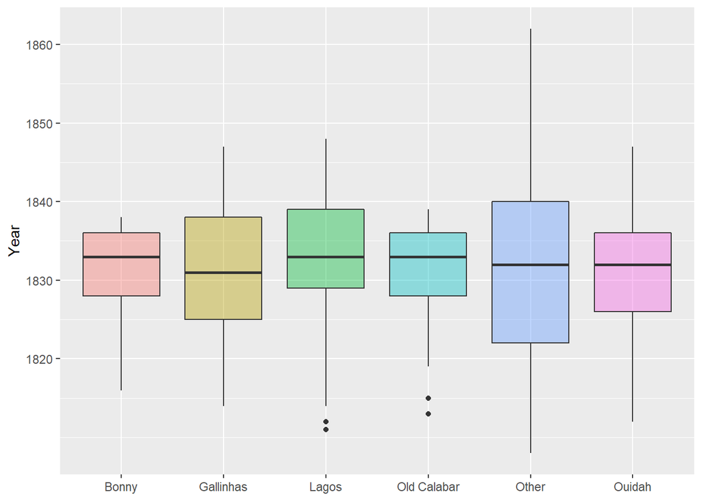

```r
african_names %>%
               add_count(port_embark) %>%
               mutate(port_embark = case_when(
                              n < 4000 ~ 'Other',
                              TRUE~ port_embark
               )) %>%
               ggplot(aes(x = port_embark, y = year_arrival, fill = port_embark)) +
               geom_boxplot(alpha = 0.4, show.legend = FALSE) +
               labs(x = NULL, y = 'Year') + scale_y_continuous(breaks = 100*seq(18.2, 18.7, by=0.1))
```

When is this data from?

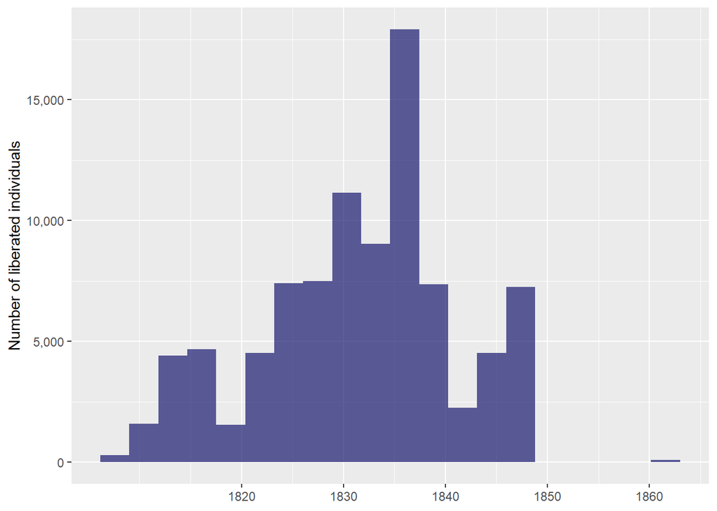

```r
african_names %>% ggplot(aes(year_arrival)) +
               geom_histogram(bins = 20, fill = 'midnightblue', alpha = 0.7)+
               scale_y_continuous(labels = scales:: comma_format()) +
               labs(
                              y = 'Number of liberated individuals',
                              x = NULL
               ) + scale_x_continuous(breaks = 100*seq(18.2, 18.7, by = 0.1))
```

What is the pattern of missing data?

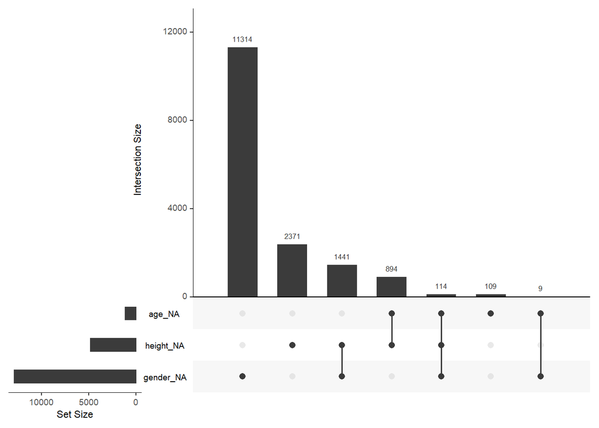

```r
library(naniar)
african_names %>%
               select(gender, age, height, year_arrival) %>%
               gg_miss_upset()
```

What is the relationship between gender and year of arrival?

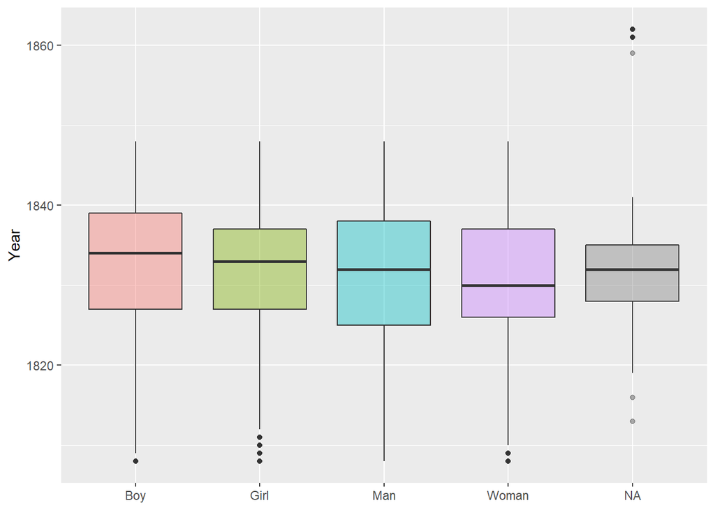

```r
african_names %>%
               ggplot(aes( x = gender, y = year_arrival, fill = gender)) +
               geom_boxplot(alpha = 0.4, show.legend = FALSE) +
               labs(x = NULL, y = 'Year')
```

Gender was coded as both man/woman and boy/girl, but there is a fair amount of overlap in ages (children coded as “man”, for example)

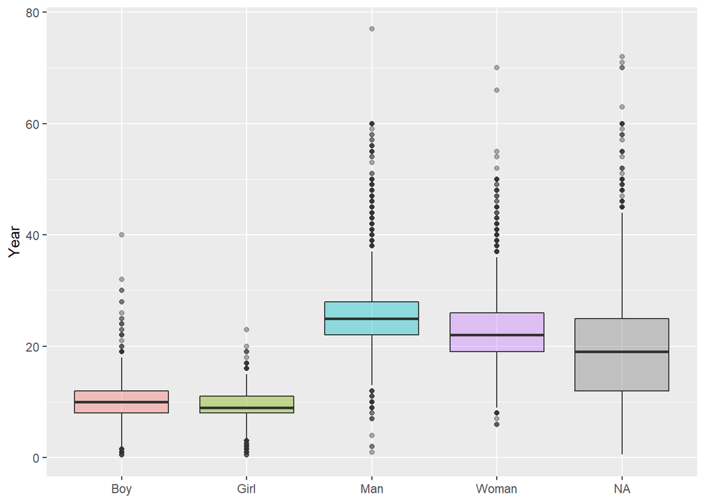

```r
african_names %>%
               ggplot(aes(x= gender, y = age, fill = gender)) +
               geom_boxplot(alpha = 0.4, show.legend = FALSE) +
               labs(x = NULL, y = 'Year')
```

What is the relationship between age and year of arrival?

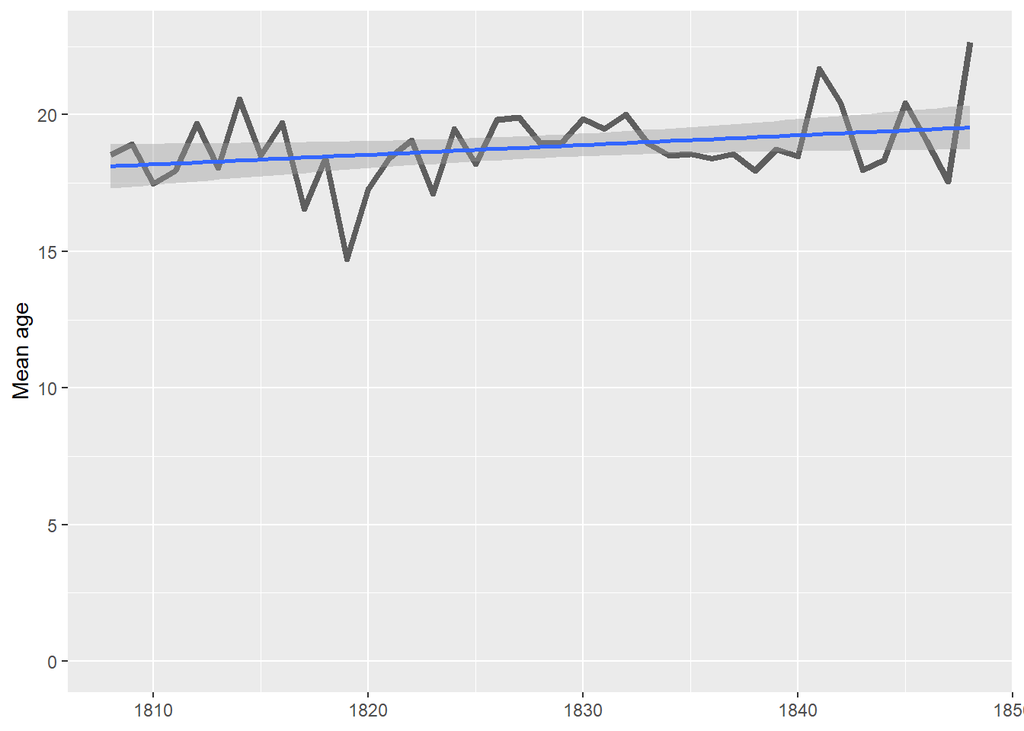

```r
african_names %>%
               filter(year_arrival < 1850) %>%
               group_by(year_arrival) %>%
               summarise(age = mean(age, na.rm = TRUE)) %>%
               ggplot(aes(x = year_arrival, y = age)) +
               geom_line(alpha = 0.6, size = 1.5) +
               geom_smooth(method = 'lm') +
               scale_y_continuous(limits = c(0,NA)) +
               labs(x = NULL, y = 'Mean age')
```

Overall, the age is drifting up slightly, although the previous plot on boys/girls/men/women calls this into question. We can use modeling to explore this better

One of the most unique and valuable characteristics of this dataset is the names. We can make a scatterplot to understand more about the distribution of ages and year of arrival.

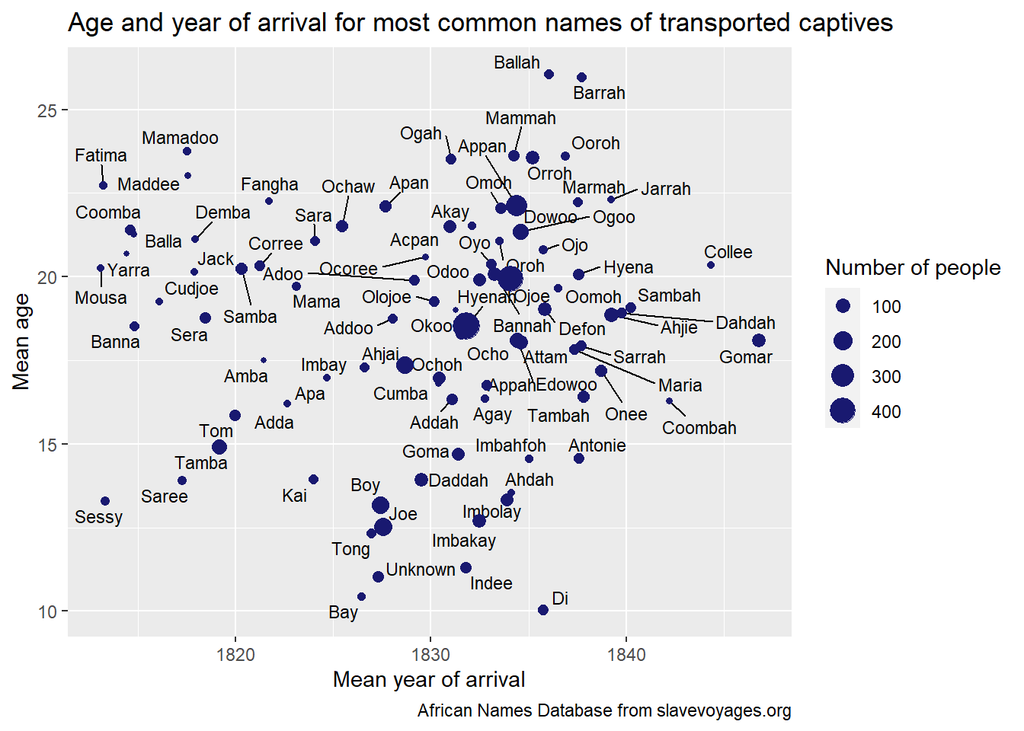

```r
library(ggrepel)

african_names %>% group_by(name) %>%
               summarise(
                              n = n(),
                              age = mean(age, na.rm = TRUE),
                              year_arrival = mean(year_arrival, na.rm = TRUE)
               ) %>%
               ungroup() %>%
               arrange(-n) %>%
               filter(n > 30) %>%
               ggplot(aes(x = year_arrival, y = age)) +
               geom_text_repel(aes(label = name), size = 3, family = 'IBMPlexSans') +
               geom_point(aes(size = n), color = 'midnightblue', alphaa = 0.7) +
               labs(
                              x = 'Mean year of arrival', y = 'Mean age',
                              size = 'Number of people',
                              title = 'Age and year of arrival for most common names of transported captives',
                              caption = 'African Names Database from slavevoyages.org'
               )
```

## Impute missing data

- Our modeling goal is to estimate whether some characteristics, say age and gender, of trafficked Africans changed during this time period. Some data is missing, so let’s try to impute gender and age, with the help of height. When we do imputation, we aren’t adding new information to our dataset, but we are using the patterns in our dataset so that we don’t have to throw away the data that have some variables missing

First, let’s filter to only the dat a from before 1850 and recode the `gender` variable

```r
liberated_df <- african_names %>%
               filter(year_arrival < 1850) %>%
               mutate(gender = case_when(
                              gender == 'Boy' ~ 'Man',
                              gender == 'Girl' ~ 'Woman',
                              TRUE ~ gender
               )) %>%
               mutate_if(is.character, factor)

liberated_df
```

```
## # A tibble: 91,394 x 11
##       id voyage_id name  gender   age height ship_name year_arrival
##    <dbl>     <dbl> <fct> <fct>  <dbl>  <dbl> <fct>            <dbl>
##  1     1      2314 Bora  Man       30   62.5 NS de Re~         1819
##  2     2      2315 Flam  Man       30   64   Fabiana           1819
##  3     3      2315 Dee   Man       28   65   Fabiana           1819
##  4     4      2315 Pao   Man       22   62.5 Fabiana           1819
##  5     5      2315 Mufa  Man       16   59   Fabiana           1819
##  6     6      2315 Latty Man       22   67.5 Fabiana           1819
##  7     7      2315 So    Man       20   62   Fabiana           1819
##  8     8      2315 Trua  Man       30   65.5 Fabiana           1819
##  9     9      2315 Tou   Man       18   61.5 Fabiana           1819
## 10    10      2315 Quaco Man       23   62   Fabiana           1819
## # ... with 91,384 more rows, and 3 more variables: port_disembark <fct>,
## #   port_embark <fct>, country_origin <fct>
```

Next, let’s impute the missing data using a recipe

```r
library(recipes)

impute_rec <- recipe(year_arrival ~ gender + age + height, data = liberated_df) %>%
               step_meanimpute(height) %>%
               step_knnimpute(all_predictors())
```

Let’s walk through the steps in this recipe

- First, we must tell the `recipe()` what’s going on with our model what data we are using (notice we did not split into training and testing, because of our specific modeling goals)
- Next, we impute the missing values for height with the mean value of height. height has a low values of missingness. and we are only going to use it to impute age and gender, not for modeling
- Next, we impute the missing values for age and gender using a nearest neighbors model with all three predictors

Once we have the recipe defined, we can estimate the parameters needed to apply it using `prep()` function. In this case, that means finding the mean for height (fast) and training the nearest neighbor model to find gender and age (not) so fast). Then we can use `juice()` to get that imputed data back out. (If we wanted to apply the recipe to other data, like new data we hadn’t seen before, we would use `bake()` instead).

```r
imputed <- prep(impute_rec) %>% juice()
```

How did the imputation turn out?

```r
summary(liberated_df$age)
```

```
##    Min. 1st Qu.  Median    Mean 3rd Qu.    Max.    NA's
##    0.50   11.00   20.00   18.89   26.00   77.00    1030
```

```r
summary(imputed$age)
```

```
##    Min. 1st Qu.  Median    Mean 3rd Qu.    Max.
##    0.50   11.00   19.00   18.77   26.00   77.00
```

```r
summary(liberated_df$gender)
```

```
##   Man Woman  NA's
## 52723 25889 12782
```

```r
summary(imputed$gender)
```

```
##   Man Woman
## 60992 30402
```

No more NA values, and the distributions look about the same. I like to keep in mind that the point of imputation like this is to be able to use the information we have in the dataset without throwing it away, which feels especially important when dealing with historical data on individuals who experienced enslavement.

## Fit a model

The distribution of year of arrival was a bit wonky, so that is good to keep in mind when training a linear model.

```r
fit_lm <- lm(year_arrival ~ gender + age, data = imputed)
```

We can check out the model results.

```r
summary(fit_lm)
```

```
##
## Call:
## lm(formula = year_arrival ~ gender + age, data = imputed)
##
## Residuals:
##      Min       1Q   Median       3Q      Max
## -23.7206  -5.3343   0.9842   5.6828  17.0903
##
## Coefficients:
##               Estimate Std. Error   t value Pr(>|t|)
## (Intercept)  1.832e+03  8.163e-02 22440.485  < 2e-16 ***
## genderWoman -3.014e-01  6.724e-02    -4.482 7.40e-06 ***
## age         -2.123e-02  3.665e-03    -5.793 6.95e-09 ***
## ---
## Signif. codes:  0 '***' 0.001 '**' 0.01 '*' 0.05 '.' 0.1 ' ' 1
##
## Residual standard error: 9.476 on 91391 degrees of freedom
## Multiple R-squared:  0.0005149,  Adjusted R-squared:  0.000493
## F-statistic: 23.54 on 2 and 91391 DF,  p-value: 6.012e-11
```

```r
tidy(fit_lm) %>%
  kable(digits = 3)
```

| term | estimate | std.error | statistic | p.value |
| --- | --- | --- | --- | --- |
| (Intercept) | 1831.869 | 0.082 | 22440.485 | 0 |
| genderWoman | -0.301 | 0.067 | -4.482 | 0 |
| age | -0.021 | 0.004 | -5.793 | 0 |

During the years (about 1810 to 1850) included here, as time passed, there were some gradual shifts in the population of who was found on (i.e. liberated from) these slave ships.

- There is evidence for a modest shift to younger ages as time passed. (The plot showing increasing age with time was, it turns out, an example of Simpson’s paradox.)
- In the earlier years, there were more proportionally more women while in the later years, there were proportionally more men.